# Forest Plots

## Data Integrity

```r
df_forest %>%
  filter(category_id == "dtin") %>%
  pull(tab) %>%
  htmltools::tagList()
```

Data Integrity Related Audit and Inspection Findings

Adjusted Risk Factors

Distribution

N<sup>1</sup>

N with Findings<sup>1</sup>

Coefficient (CI95)<sup>2</sup>

Odds Ratio (CI95)

P

Coefficient Over Time (CI95)<sup>2,3</sup>

# Active Trials At Site In TA Past Year (Percent Rank)<sup>4,5</sup>

[0 - 0.4)

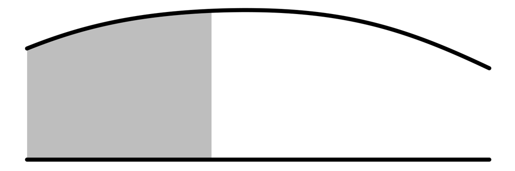

313 (39.5%)

210 (67.1%)

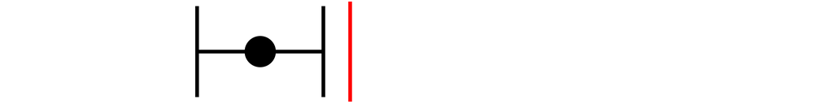

0.6 (0.5-0.9)

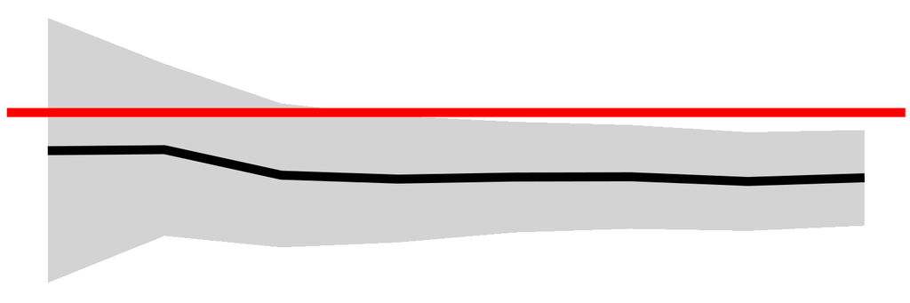

[0.4 - Inf)

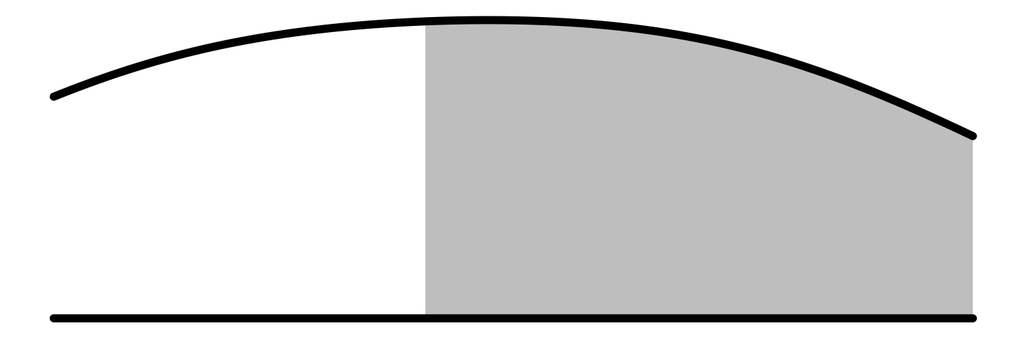

391 (49.4%)

302 (77.2%)

missing

88 (11.1%)

63 (71.6%)

# Issues Due

[0 - 2)

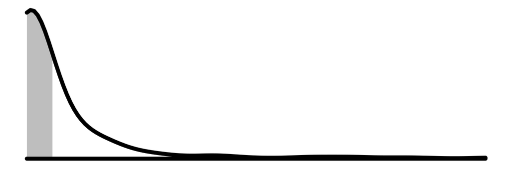

288 (36.4%)

189 (65.6%)

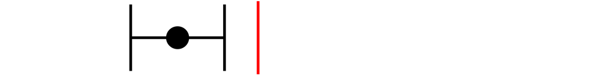

0.6 (0.4-0.8)

0.00076 ***

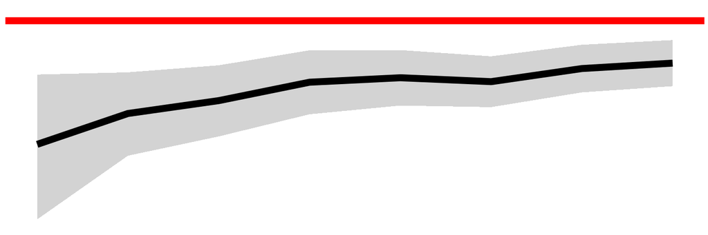

[2 - Inf)

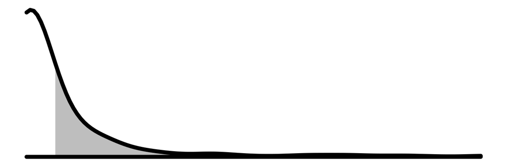

147 (18.6%)

109 (74.1%)

missing

357 (45.1%)

277 (77.6%)

# Open Queries Per Days On Study<sup>6</sup>

[0 - 0.0055)

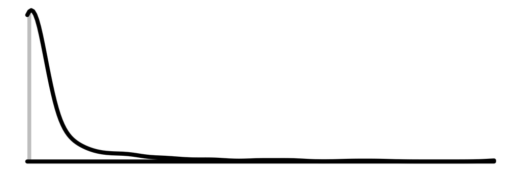

179 (22.6%)

109 (60.9%)

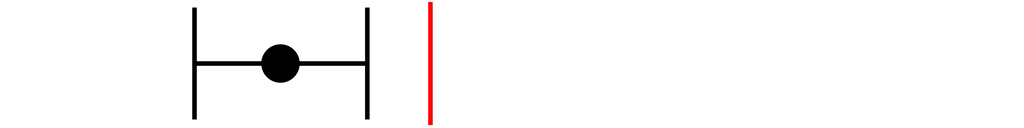

0.5 (0.4-0.8)

0.00066 ***

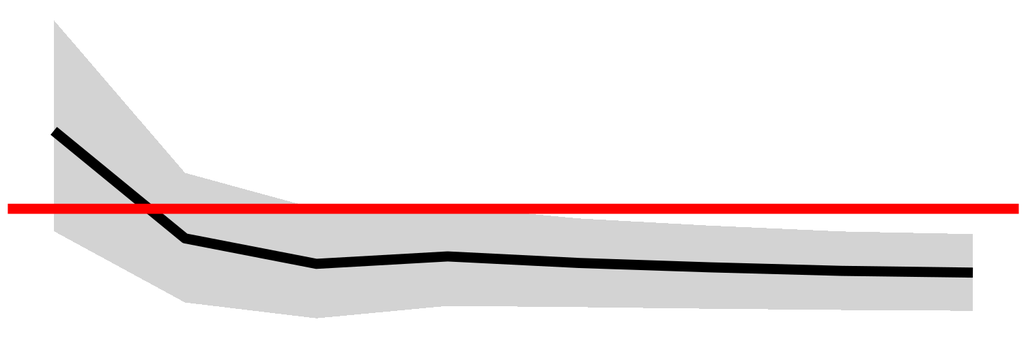

[0.0055 - Inf)

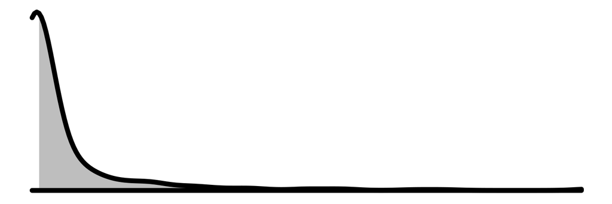

162 (20.5%)

123 (75.9%)

missing

451 (56.9%)

343 (76.1%)

Male to Female Ratio in Population with Age 18-39<sup>7</sup>

[0.46 - 0.49)

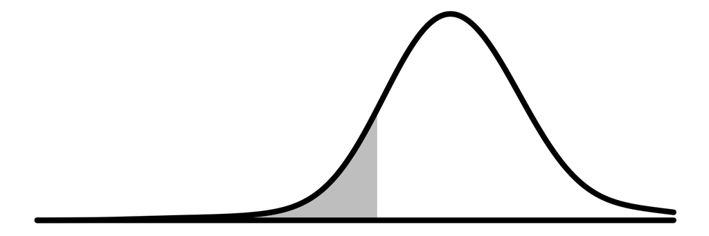

34 (4.3%)

20 (58.8%)

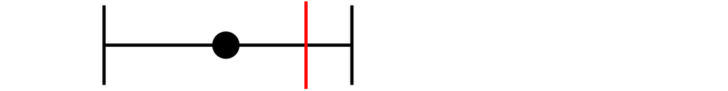

0.6 (0.3-1.3)

0.20156

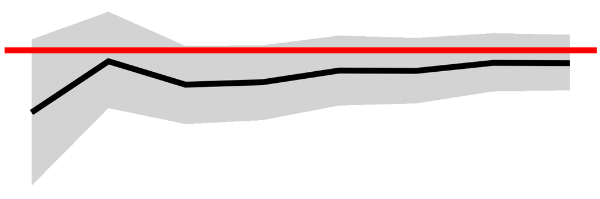

[0.49 - 0.5)

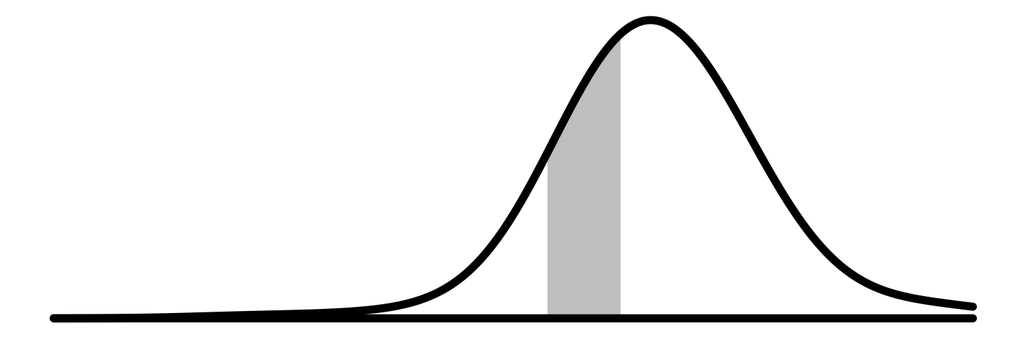

175 (22.1%)

121 (69.1%)

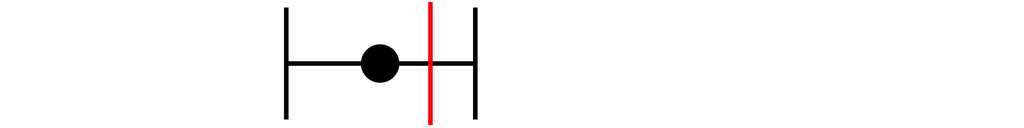

0.8 (0.5-1.2)

0.29585

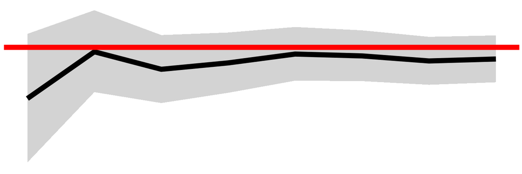

[0.5 - 0.51)

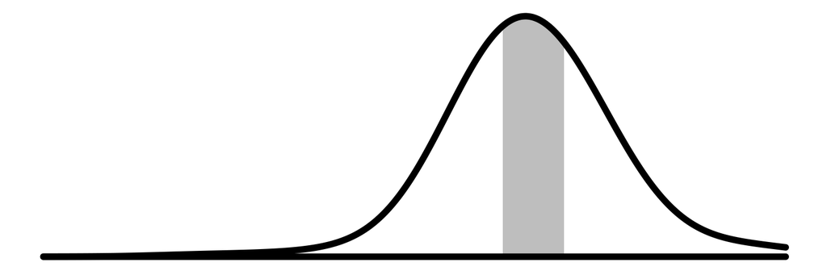

249 (31.4%)

183 (73.5%)

[0.51 - 0.52)

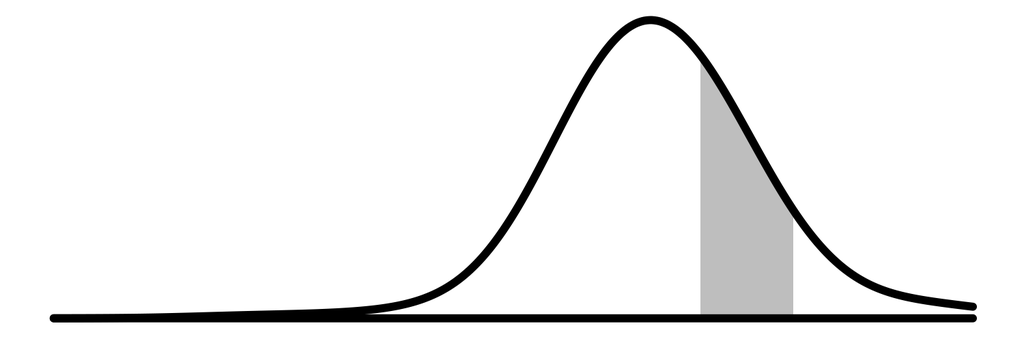

149 (18.8%)

123 (82.6%)

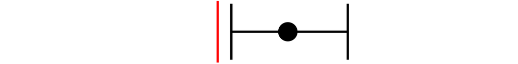

1.8 (1.1-2.9)

0.01796 *

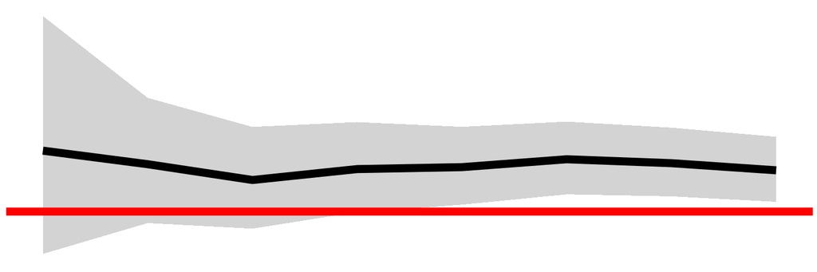

[0.52 - Inf)

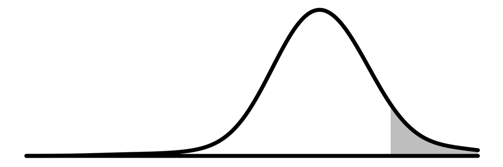

34 (4.3%)

28 (82.4%)

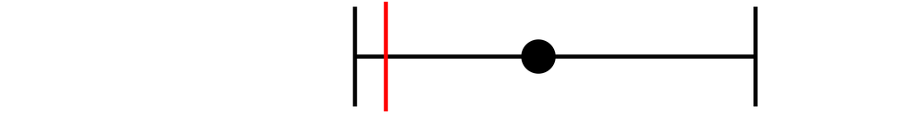

2 (0.9-5.6)

0.12908

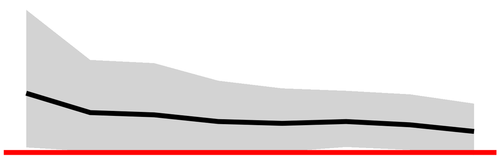

missing

151 (19.1%)

100 (66.2%)

<sup>*1*</sup> Number of Clinical Trial Site Audits and Inspections

<sup>*2*</sup> Red Reference Line Indicates Zero

<sup>*3*</sup> Coefficient Value as New Data is Successively Added from 2011-2019

<sup>*4*</sup> Percent Rank of Site Within Study

<sup>*5*</sup> Active Trials in the Past Year in the Same Theraputic Area

<sup>*6*</sup> Sum of Days Since Enrollment of All Patients

<sup>*7*</sup> Population Within 100 km Radius of Site

## Safety

```r
df_forest %>%
  filter(category_id == "sfty") %>%
  pull(tab) %>%
  htmltools::tagList()
```

Safety Related Audit and Inspection Findings

Adjusted Risk Factors

Distribution

N<sup>1</sup>

N with Findings<sup>1</sup>

Coefficient (CI95)<sup>2</sup>

Odds Ratio (CI95)

P

Coefficient Over Time (CI95)<sup>2,3</sup>

% Population with Age over 60<sup>4</sup>

[0.043 - 0.14)

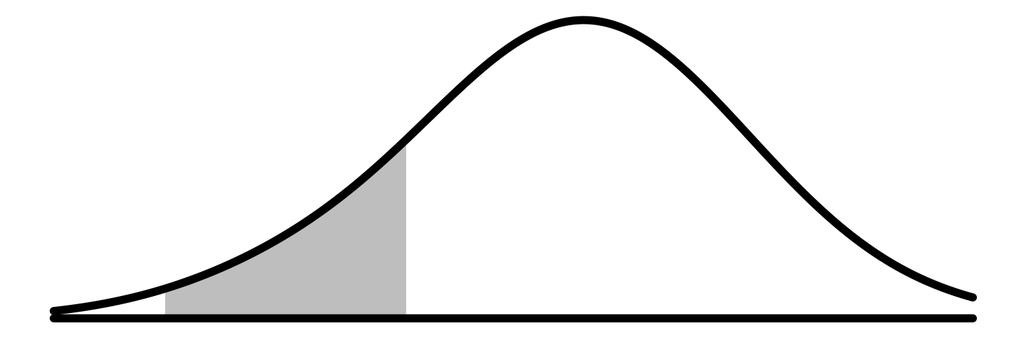

75 (9.2%)

33 (44%)

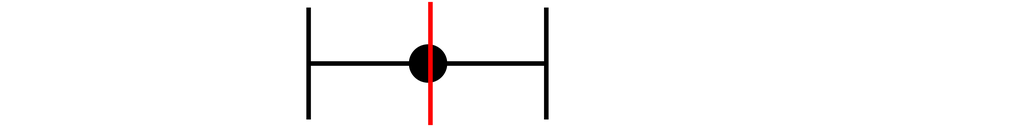

1 (0.6-1.6)

0.96856

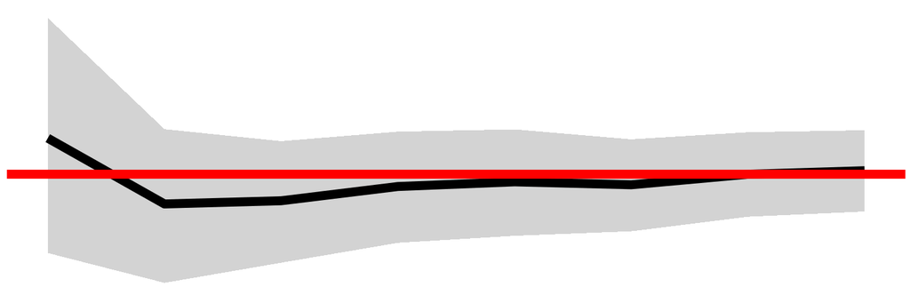

[0.14 - 0.28)

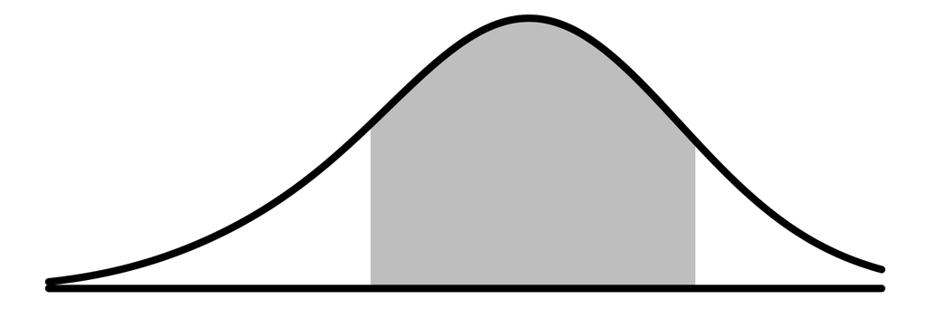

485 (59.8%)

234 (48.2%)

[0.28 - Inf)

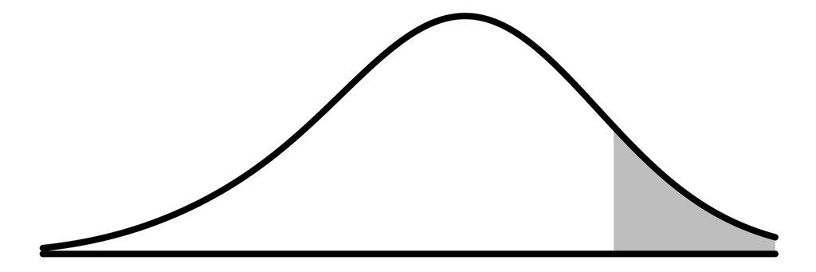

37 (4.6%)

26 (70.3%)

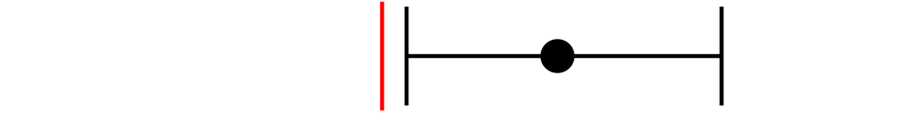

2.3 (1.1-5)

0.02759 *

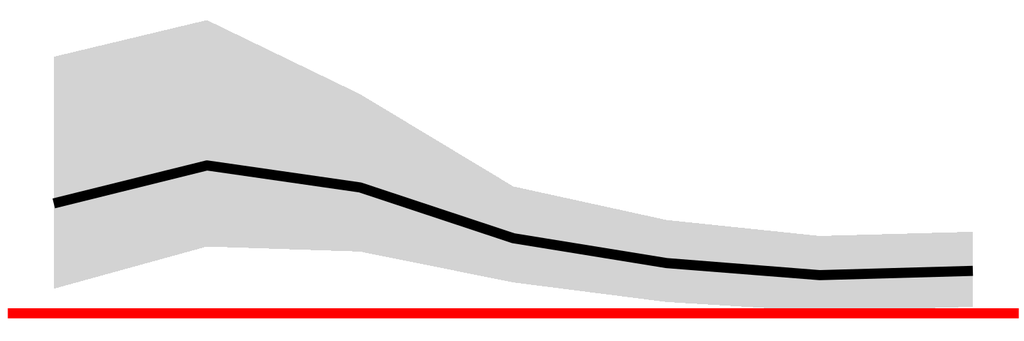

missing

214 (26.4%)

98 (45.8%)

AE Per Visit

[0 - 0.52)

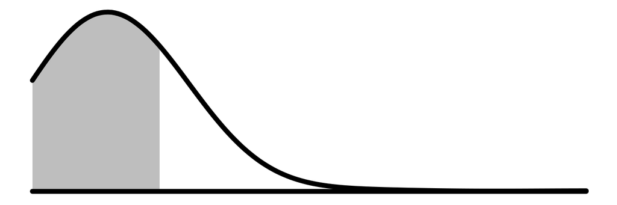

325 (40.1%)

144 (44.3%)

[0.52 - Inf)

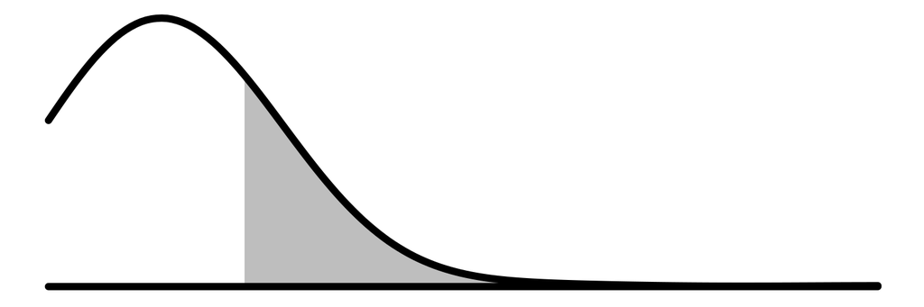

82 (10.1%)

50 (61%)

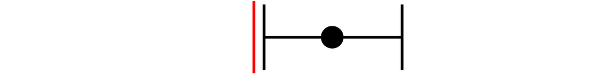

1.7 (1.1-2.9)

0.02567 *

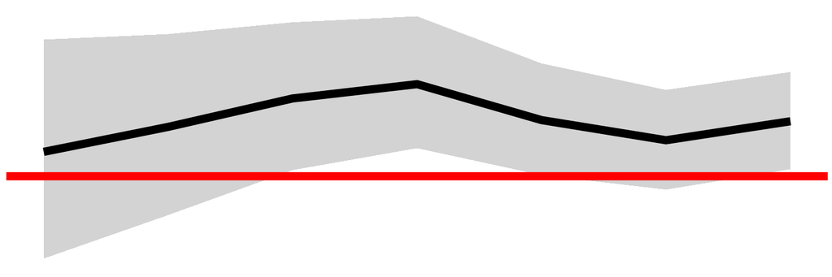

missing

404 (49.8%)

197 (48.8%)

SAE Per Visit

[0 - 0.0075)

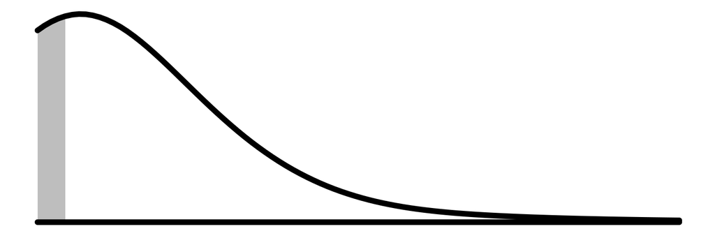

171 (21.1%)

62 (36.3%)

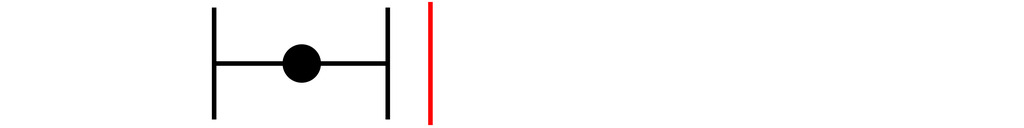

0.6 (0.4-0.8)

0.00362 **

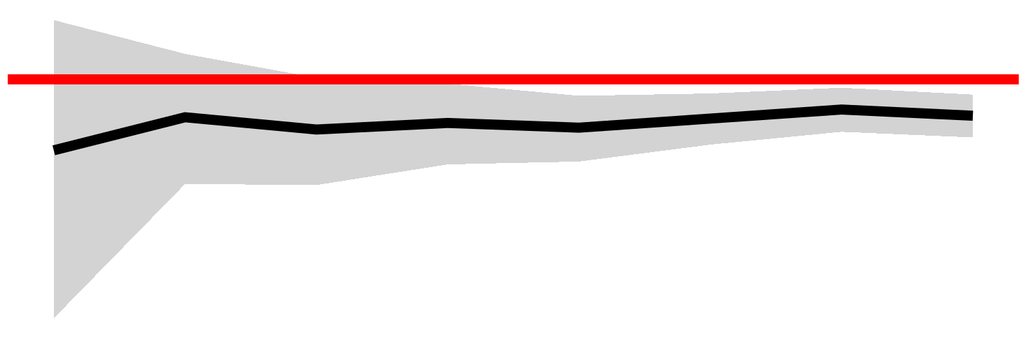

[0.0075 - Inf)

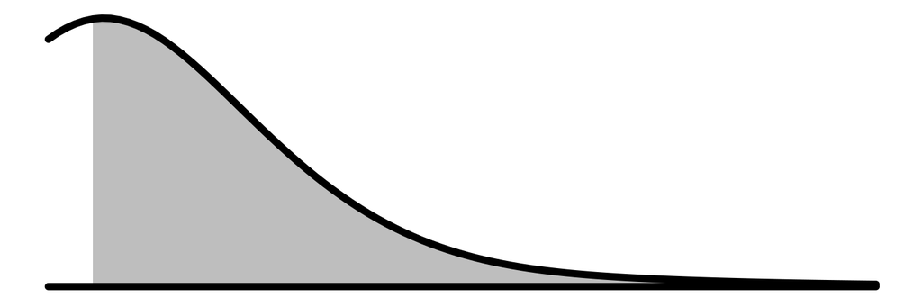

236 (29.1%)

132 (55.9%)

missing

404 (49.8%)

197 (48.8%)

Therapeutic Area

Autoimmune Disease Study

109 (13.4%)

41 (37.6%)

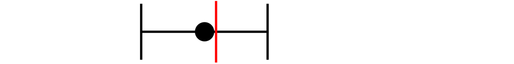

0.9 (0.5-1.5)

0.72133

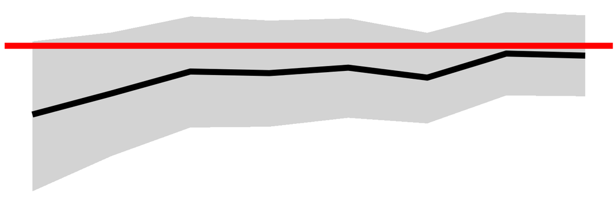

Cancer Study

460 (56.7%)

262 (57%)

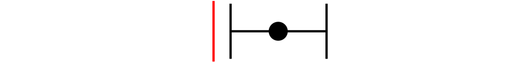

1.7 (1.2-2.6)

0.00815 *

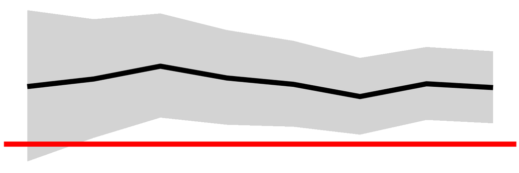

Neuro- Psychiatric Study

112 (13.8%)

36 (32.1%)

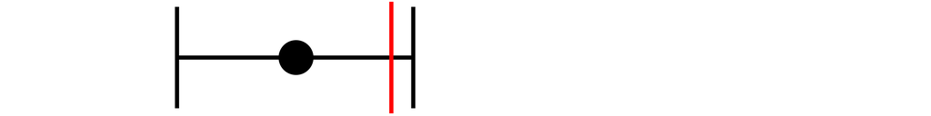

0.6 (0.4-1.1)

0.1131

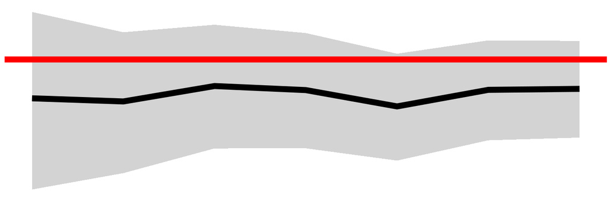

other Therapeutic Area Study

130 (16%)

52 (40%)

missing

0 (0%)

0 (0%)

<sup>*1*</sup> Number of Clinical Trial Site Audits and Inspections

<sup>*2*</sup> Red Reference Line Indicates Zero

<sup>*3*</sup> Coefficient Value as New Data is Successively Added from 2011-2019

<sup>*4*</sup> Population Within 100 km Radius of Site

## Protecting Endpoints

```r
df_forest %>%
  filter(category_id == "ptpe") %>%
  pull(tab) %>%
  htmltools::tagList()
```

Protecting The Primary Endpoint Related Audit and Inspection Findings

Adjusted Risk Factors

Distribution

N<sup>1</sup>

N with Findings<sup>1</sup>

Coefficient (CI95)<sup>2</sup>

Odds Ratio (CI95)

P

Coefficient Over Time (CI95)<sup>2,3</sup>

# Issues Late

[0 - 4)

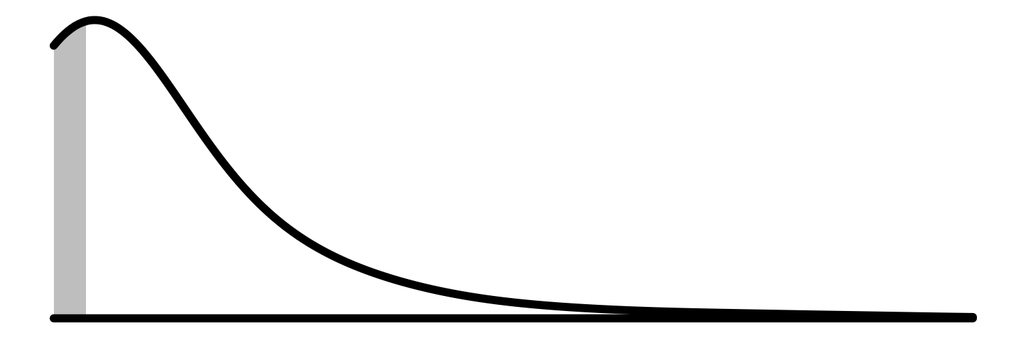

172 (27.6%)

116 (67.4%)

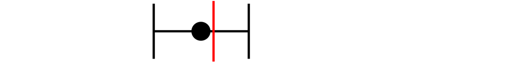

0.9 (0.6-1.3)

0.60298

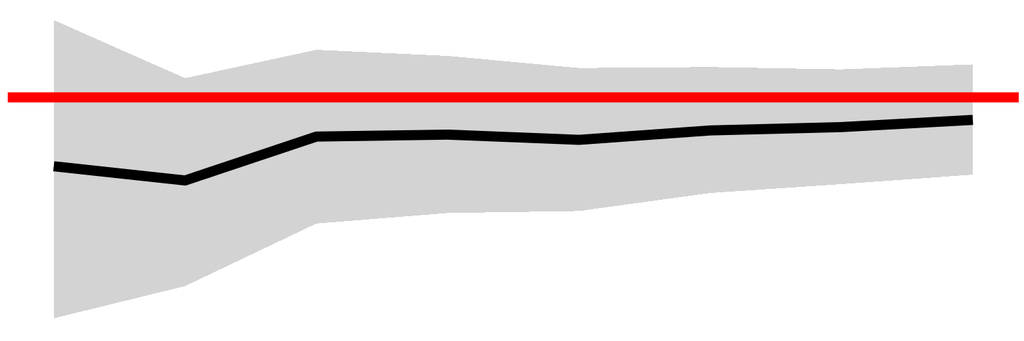

[4 - 30)

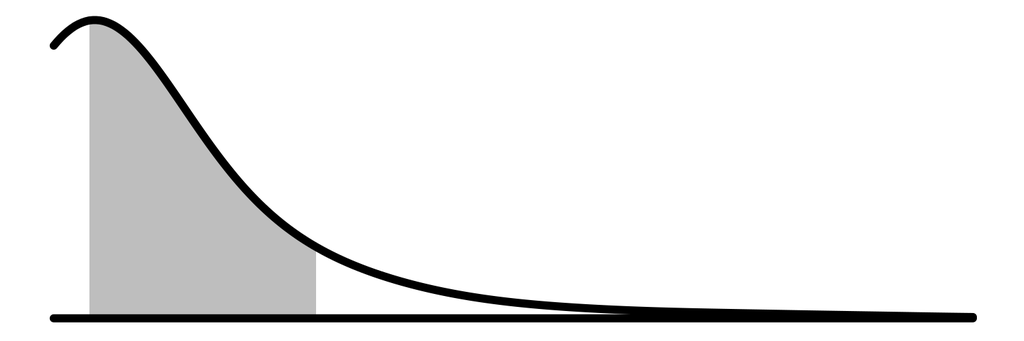

216 (34.6%)

152 (70.4%)

[30 - Inf)

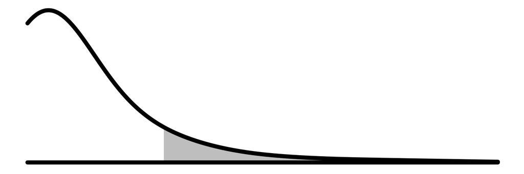

47 (7.5%)

37 (78.7%)

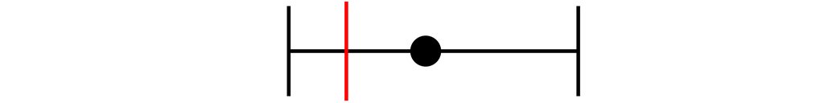

1.5 (0.7-3.4)

0.27818

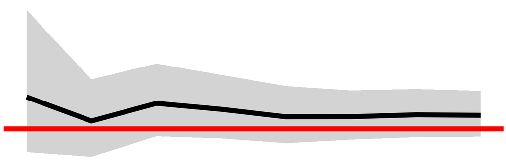

missing

189 (30.3%)

134 (70.9%)

# Minor Deviations Per Days on Study<sup>4</sup>